# Comparing NBA Performance Pre-Pandemic & Post-Pandemic

EDA Executive Summary

Author

Kayla Terrelonge

Published

November 30, 2022

## Load Packages and Data Import/Manipulation

```r
library(tidyverse)
library(dplyr)
library(lvplot)
library(stringr)
library(forcats)
library(skimr)
library(lattice)
library(gridExtra)
```

```r
# reading in data
nba_player_data <- read_csv("data/processed_data/nba_data_processed.csv")
nba_coaching_data <-read_csv("data/processed_data/coaching_data_processed.csv")

# adding pandemic status as a variable
final_nba_player_data <- nba_player_data %>%
  mutate(pandemic_status = fct_collapse(season,
                                        `pre-pandemic` = c("2001-2002","2002-2003",
                                                           "2003-2004",
                                                           "2004-2005","2005-2006",
                                                           "2006-2007",
                                                           "2007-2008","2008-2009",
                                                           "2009-2010",
                                                           "2010-2011","2011-2012",
                                                           "2012-2013","2013-2014",
                                                           "2014-2015","2015-2016",
                                                           "2016-2017", "2017-2018",
                                                           "2018-2019"),
                                        `pandemic` = c("2019-2020", "2020-2021"),
                                        `post-pandemic` = c("2021-2022")
  ),
  # fixing labeling error in data
  team = fct_collapse(team,
                               `ATL` = c("IATL","ATL"),
                               `BKN` = c("IBKN", "BKN"),
                               `BOS` = c("IBOS","BOS"),
                               `CHA` = c("ICHA", "CHA"),
                               `CHI` = c("ICHI", "CHI"),
                               `CLE` = c("ICLE", "CLE"),
                               `DEN` = c("IDEN", "DEN"),
                               `DET` = c("IDET", "DET"),
                               `IND` = c("IIND", "IND"),
                               `NO` = c("IINO", "NO"),
                               `NY` = c("IINY", "NY"),
                               `LAL` = c("ILAL", "LAL"),
                               `MEM` = c("IMEM", "MEM", "VMEM"),
                               `MIA` = c("IMIA", "MIA"),
                               `MIL` = c("IMIL", "MIL"),
                               `MIN` = c("IMIN", "MIN","VMIN"),
                               `PHI` = c("IPHI", "PHI"),
                               `SAC` = c("ISAC", "SAC"),
                               `SA` = c("IVSA", "SA"),
                               `WSH` = c("IWSH", "WSH"),
                               `POR` = c("VPOR", "POR", "IPOR"),
                               `GS` = c("IIGS", "GS"),
                               `HOU` = c("IHOU", "HOU"),
                               `OKC` = c("IOKC", "OKC"),
                               `ORL` = c("IORL", "ORL"),
                               `TOR` = c("ITOR", "TOR"),
    ))

# repeating process with coaching data set
final_nba_coaching_data <-
  nba_coaching_data %>%
  # fixing labeling error
  mutate(team = fct_collapse(team,
                             `CHA` = c("CHO", "CHA", "CHH"),
                             `BKN` = c("BRK"),
                             `GS` = c("GSW"),
                             `UTAH` = c("UTA"),
                             `NJ` = c("NJN"),
                             `NO` = c("NOH", "NOK", "NOP"),
                             `NY` = c("NYK"),
                             `PHX` = c("PHO"),
                             `WSH` = c("WAS"),
                             `SA` = c("SAS")

  ),
  # adding pandemic status
pandemic_status = fct_collapse(season,
                                        `pre-pandemic` = c("2001-2002","2002-2003", "2003-2004",
                                                           "2004-2005","2005-2006","2006-2007",
                                                           "2007-2008","2008-2009","2009-2010",
                                                           "2010-2011","2011-2012",
                                                           "2012-2013","2013-2014",
                                                           "2014-2015","2015-2016",
                                                           "2016-2017", "2017-2018","2018-2019"),
                                        `pandemic` = c("2019-2020", "2020-2021"),
                                        `post-pandemic` = c("2021-2022")
  ))

# merging data for multiple data set analysis
merged_nba_data <-
  full_join(final_nba_player_data, final_nba_coaching_data)
```

## Summary

### Introduction

The purpose of the investigation that will be summarized in the following summary was to determine if there was a relationship between the pandemic and the performance of NBA players, with a particular interest in observing a relationship between decreased performance during and after the pandemic. As for the major findings of this investigation, there was no correlation or obvious trend linking a decrease in player performance to the pandemic, however the pandemic did change several trends in terms of player performance.

### Interesting Findings

After conducting a full length Exploratory Data Analysis on the data imported above the most interesting finding is how the pandemic has seemingly increased variation in NBA players field goal performance. As shown in the plot below, during pre-pandemic times, NBA Players had less variation in their field performance, which is shocking given the size of the pre-pandemic data. It would be expected that a larger data set provides more values, with a more randomized set of values. Given this finding, the variation in NBA player performance can be attributed to factors that prevent players from playing the game, such as COVID infections, lack of compliance with COVID restrictions, or post COVID infections side effects.

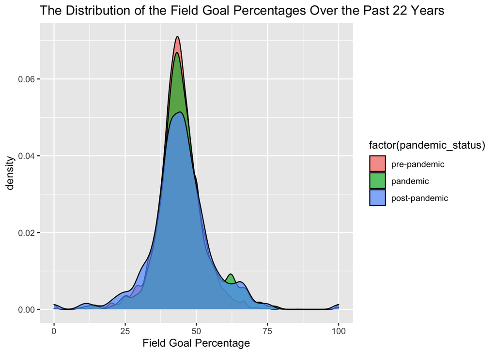

```r
p1 <- final_nba_player_data %>%
  group_by(pandemic_status) %>%
  filter(pandemic_status != "NA") %>%
  ggplot(mapping = aes(`FG%`)) +
  geom_density(aes(fill=factor(pandemic_status)), alpha = 0.7) +
  labs(title = "The Distribution of the Field Goal Percentages Over the Past 22 Years",
       x = "Field Goal Percentage")

p1
```

Another interesting aspect of the data collected and analyzed for this investigation is that the pandemic ended a relatively strong trend between the years a coach spent with a team and the average `FG%` of that team. The pre-pandemic trend is expected as a coach spends more time with a team, they are able to learn the best teaching methods for the team, the strengths and weaknesses of the team, and how to utilize them. However, during and after the pandemic, the opposite occurs and coaches with more than ten years of experience tend to have a steady decrease in their teams average `FG%`. This is the most interesting aspect from the findings as it is understandable that the trend may change slightly during the pandemic, but overall keep the same generalization. But, for the entire trend to be altered in such a drastic method is interesting as it indicates the drastic effects of the pandemic on every aspect, including sports, while also highlighting how changes caused by the pandemic will have long term effects, as this trend has lasted after the ending of the pandemic.

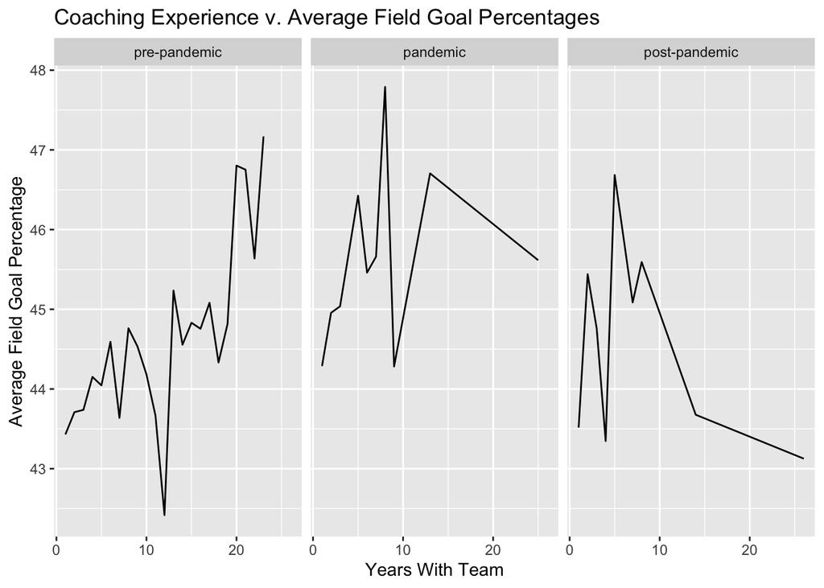

```r
p2 <- merged_nba_data %>%
  group_by(pandemic_status, year_w_team) %>%
  filter(pandemic_status != "NA") %>%
  summarise(mean = mean(`FG%`)) %>%
  ggplot(mapping = aes(x = year_w_team, y = mean)) +
  geom_line()+
  facet_wrap(~pandemic_status) +
  labs(title = "Coaching Experience v. Average Field Goal Percentages ",
       x = "Years With Team",
       y = "Average Field Goal Percentage")

p2
```

## References

[NBA Player Data](https://www.espn.com/nba/stats) [NBA Coaching Data](https://www.basketball-reference.com/leagues/NBA_2020_coaches.html)